# randomForest_example

### Trees and Forests

The examples below are meant to give a high level introduction to the use of decision trees and random forests. The article that we looked at uses Random Forests to determine information about the appropriate color for a map. These are quantitative questions and lead to the use of a **regression** tree. Despite the use of categorical problems and hence, use **classification** trees, the libraries in R discriminate between these questions on their own, and the implementation is consistent.

Let's again consider the introductory paragraph from [*Mapping Coral Reef Resilience Indicators Using Field and Remotely Sensed Data*](http://www.mdpi.com/2072-4292/5/3/1311).

> Two types of predictive model were used to produce maps of each resilience indicator: random forest [69] and universal kriging [70] (Figure 2). Random forest is a non-parametric ensemble classifier that predicts the value of a single response variable from the values of multiple predictors; this model type has previously been shown to outperform other regression model types for modelling ecosystem variables in coral reef environments [47,71]. A random forest model is composed of multiple regression trees [72], where splits at each node in each tree are based on a random subset of the available predictors [69]. For each resilience indicator, a model was trained on a data set consisting of the observed values of the indicator at the field sites (the response) and the values of all environmental data layers at the field site locations (the predictors). Model development was done using R [73], using the “randomForest” package [74]. Default values were used for random forest parameters, except for the number of trees in each forest and the number of predictors used to partition the data at each node. These two parameters were optimized with internal 5-fold cross-validation for each training partition, where the combination producing the lowest error value, quantified as the root mean square error (RMSE), within the training set was used.

The scientists used data from field stations to generalize and produce maps as shown below. The big idea is how do you use multiple measures to classify some unknown measurement -- whether this is categorical or numeric. You can see that the colors are determined by a range of values. These ranges outside of the dots for the field stations have been determined by the `randomForest` and universal krigging models.

[figure not shown]

```r
library(tidyverse)
library(titanic)
```

### Decision Tree Problems

To get started, consider a dataset dealing with passengers on the titanic. We can use the `titanic` library that has some data already set up for us. After installing the library if you haven't, we can call the `train` set that we will use to develop our model.

```r
head(titanic_train)
```

| PassengerId | Survived | Pclass | Name | Sex | Age | SibSp | Parch | Ticket | Fare | Cabin | Embarked |
| --- | --- | --- | --- | --- | --- | --- | --- | --- | --- | --- | --- |
| 1 | 0 | 3 | Braund, Mr. Owen Harris | male | 22 | 1 | 0 | A/5 21171 | 7.2500 |  | S |
| 2 | 1 | 1 | Cumings, Mrs. John Bradley (Florence Briggs Thayer) | female | 38 | 1 | 0 | PC 17599 | 71.2833 | C85 | C |
| 3 | 1 | 3 | Heikkinen, Miss. Laina | female | 26 | 0 | 0 | STON/O2. 3101282 | 7.9250 |  | S |
| 4 | 1 | 1 | Futrelle, Mrs. Jacques Heath (Lily May Peel) | female | 35 | 1 | 0 | 113803 | 53.1000 | C123 | S |
| 5 | 0 | 3 | Allen, Mr. William Henry | male | 35 | 0 | 0 | 373450 | 8.0500 |  | S |
| 6 | 0 | 3 | Moran, Mr. James | male | NA | 0 | 0 | 330877 | 8.4583 |  | Q |

### Test and Train Splits

The titanic data has already been divided into a **train** and **test** set. The train set is what we will use to build our model on, while the test set will be used to determine how good the model we built is. This is a fundamental characteristic of the machine learning approach.

```r
str(titanic_train)
```

```
'data.frame':	891 obs. of  12 variables:
 $ PassengerId: int  1 2 3 4 5 6 7 8 9 10 ...
 $ Survived   : int  0 1 1 1 0 0 0 0 1 1 ...
 $ Pclass     : int  3 1 3 1 3 3 1 3 3 2 ...
 $ Name       : chr  "Braund, Mr. Owen Harris" "Cumings, Mrs. John Bradley (Florence Briggs Thayer)" "Heikkinen, Miss. Laina" "Futrelle, Mrs. Jacques Heath (Lily May Peel)" ...
 $ Sex        : chr  "male" "female" "female" "female" ...
 $ Age        : num  22 38 26 35 35 NA 54 2 27 14 ...
 $ SibSp      : int  1 1 0 1 0 0 0 3 0 1 ...
 $ Parch      : int  0 0 0 0 0 0 0 1 2 0 ...
 $ Ticket     : chr  "A/5 21171" "PC 17599" "STON/O2. 3101282" "113803" ...
 $ Fare       : num  7.25 71.28 7.92 53.1 8.05 ...
 $ Cabin      : chr  "" "C85" "" "C123" ...
 $ Embarked   : chr  "S" "C" "S" "S" ...
```

```r
str(titanic_test)
```

```
'data.frame':	418 obs. of  11 variables:
 $ PassengerId: int  892 893 894 895 896 897 898 899 900 901 ...
 $ Pclass     : int  3 3 2 3 3 3 3 2 3 3 ...
 $ Name       : chr  "Kelly, Mr. James" "Wilkes, Mrs. James (Ellen Needs)" "Myles, Mr. Thomas Francis" "Wirz, Mr. Albert" ...
 $ Sex        : chr  "male" "female" "male" "male" ...
 $ Age        : num  34.5 47 62 27 22 14 30 26 18 21 ...
 $ SibSp      : int  0 1 0 0 1 0 0 1 0 2 ...
 $ Parch      : int  0 0 0 0 1 0 0 1 0 0 ...
 $ Ticket     : chr  "330911" "363272" "240276" "315154" ...
 $ Fare       : num  7.83 7 9.69 8.66 12.29 ...
 $ Cabin      : chr  "" "" "" "" ...
 $ Embarked   : chr  "Q" "S" "Q" "S" ...
```

### Basic Iive or die

Our dataset has a column named `Survived` that has a 0 for those passengers who died, and a 1 for those who survived. We can examine the counts of these values with the `table` function. By adding using the `prop.table` function, we can view these as proportions.

```r
table(titanic_train$Survived)
```

```
  0   1
549 342
```

```r
prop.table(table(titanic_train$Survived))
```

```
        0         1
0.6161616 0.3838384
```

**Two Way Tables**

Did more women or men survive? Here we want to consider two variables, both Sex and Survived. We make a two way table by including the two values in the `table` call.

```r
table(titanic_train$Survived, titanic_train$Sex)
```

```
    female male
  0     81  468
  1    233  109
```

```r
#row wise proportions
prop.table(table(titanic_train$Sex, titanic_train$Survived), margin = 1)
```

```
                 0         1
  female 0.2579618 0.7420382
  male   0.8110919 0.1889081
```

```r
#column wise proportions
prop.table(table(titanic_train$Sex, titanic_train$Survived), margin = 2)
```

```
                 0         1
  female 0.1475410 0.6812865
  male   0.8524590 0.3187135
```

```r
titanic_train$child  <- NA
```

```r
titanic_train$child[titanic_train$Age <= 18]  <- TRUE
titanic_train$child[titanic_train$Age > 18]  <- FALSE
```

```r
table(titanic_train$child)
```

```
FALSE  TRUE
  575   139
```

```r
table(titanic_train$child, titanic_train$Survived)
```

```
          0   1
  FALSE 355 220
  TRUE   69  70
```

```r
prop.table(table(titanic_train$child, titanic_train$Survived))
```

```
                 0          1
  FALSE 0.49719888 0.30812325
  TRUE  0.09663866 0.09803922
```

```r
titanic_test$Survived  <- 0
```

```r
titanic_test$Survived[titanic_test$Sex == "female"]  <- 1
```

### Decision Tree

Suppose with the titanic data, we wanted to determine the most important factors for a passenger surviving. Perhaps we ask the question of whether sex or age were more important determinants.

```r
library(rpart)
```

```r
tree  <- rpart(Survived ~ Sex + Age, data = titanic_train, method = "class")
```

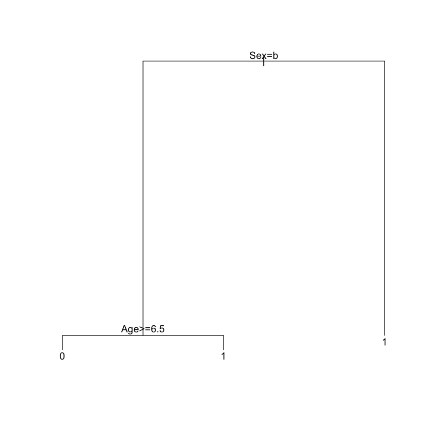

```r
plot(tree)
text(tree)
```

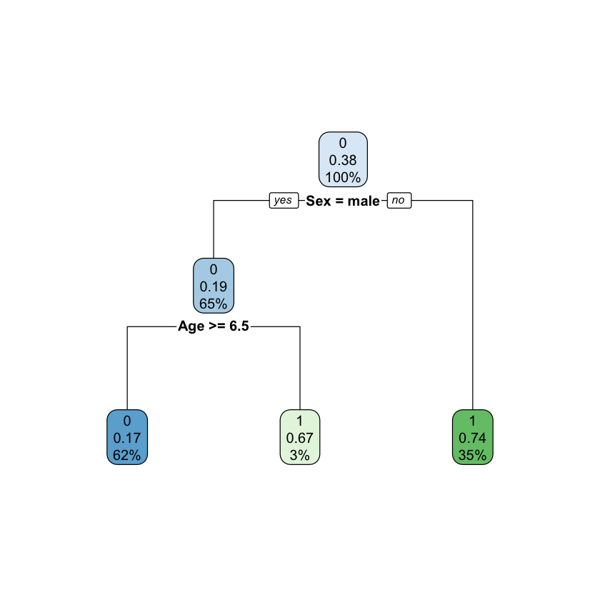

```r
library(rpart.plot)
rpart.plot(tree)
```

According to the decision tree, sex was a more important factor in survival than age.

### Random Forest's

The notion of the decision tree is straightforward, however by using a single tree we can run into the problem of overfitting a model and losing predictive power. A **Random Forest** builds a bunch of trees and uses the results across them to determine the model. Rather than visualizing a tree itself, we will look at the results of all the trees being averaged to understand the variable importance.

Below, we can examine the iris dataset that contains measurements from three different species of flowers. We could ask which of these measurements is a better predictor of species. Here, we can compare the results of a decision tree to that of forest of trees. We will first load the `randomForest` library, and chop the iris data into two pieces: the quantitative measurements and the species categories.

```r
library(randomForest)
```

```r
measurements = iris[,-5]
head(measurements)
```

| Sepal.Length | Sepal.Width | Petal.Length | Petal.Width |
| --- | --- | --- | --- |
| 5.1 | 3.5 | 1.4 | 0.2 |
| 4.9 | 3.0 | 1.4 | 0.2 |
| 4.7 | 3.2 | 1.3 | 0.2 |
| 4.6 | 3.1 | 1.5 | 0.2 |
| 5.0 | 3.6 | 1.4 | 0.2 |
| 5.4 | 3.9 | 1.7 | 0.4 |

```r
species = iris[,5]
head(species)
```

1. setosa

2. setosa

3. setosa

4. setosa

5. setosa

6. setosa

```r
fit  <- randomForest(measurements, species, importance = TRUE)
```

```r
summary(fit)
```

```
                Length Class  Mode
call               4   -none- call
type               1   -none- character
predicted        150   factor numeric
err.rate        2000   -none- numeric
confusion         12   -none- numeric
votes            450   matrix numeric
oob.times        150   -none- numeric
classes            3   -none- character
importance        20   -none- numeric
importanceSD      16   -none- numeric
localImportance    0   -none- NULL
proximity          0   -none- NULL
ntree              1   -none- numeric
mtry               1   -none- numeric
forest            14   -none- list
y                150   factor numeric
test               0   -none- NULL
inbag              0   -none- NULL
```

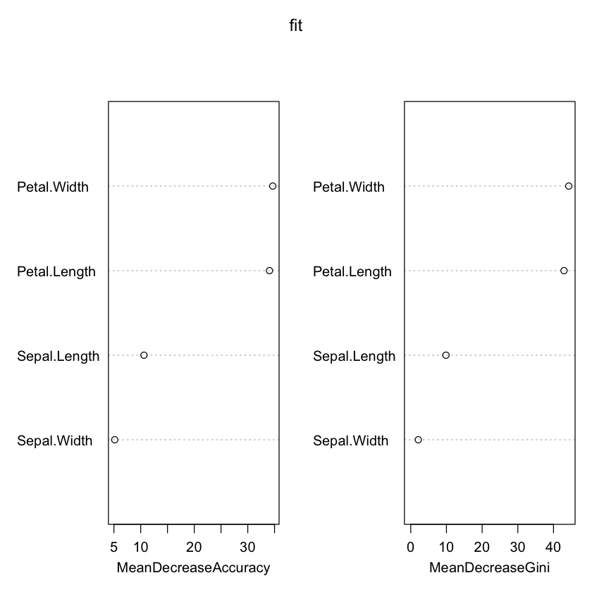

```r
varImpPlot(fit)
```

```r
fit
```

```
Call:
 randomForest(x = measurements, y = species, importance = TRUE)
               Type of random forest: classification
                     Number of trees: 500
No. of variables tried at each split: 2

        OOB estimate of  error rate: 4%
Confusion matrix:
           setosa versicolor virginica class.error
setosa         50          0         0        0.00
versicolor      0         47         3        0.06
virginica       0          3        47        0.06
```

### Comparing to Tree

Using the same syntax as earlier, we can investigate how a single tree would split the data.

```r
fit2  <- rpart(Species ~ Sepal.Width + Petal.Length + Petal.Width, data = iris)
```

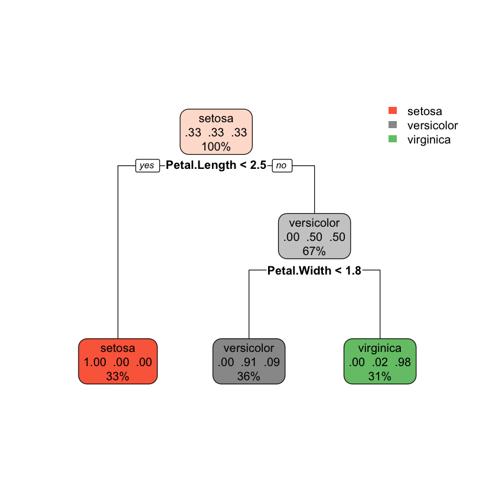

```r
rpart.plot(fit2)
```

```r
fit2
```

[output not shown]

### Back to Titanic

Now, you could use the `randomForest` approach to determining survival on the titanic. Additionally, you can compare this to how your model compares to a single decision tree.

```r
library(titanic)
```

```r
head(titanic_train)
```

| PassengerId | Survived | Pclass | Name | Sex | Age | SibSp | Parch | Ticket | Fare | Cabin | Embarked |
| --- | --- | --- | --- | --- | --- | --- | --- | --- | --- | --- | --- |
| 1 | 0 | 3 | Braund, Mr. Owen Harris | male | 22 | 1 | 0 | A/5 21171 | 7.2500 |  | S |
| 2 | 1 | 1 | Cumings, Mrs. John Bradley (Florence Briggs Thayer) | female | 38 | 1 | 0 | PC 17599 | 71.2833 | C85 | C |
| 3 | 1 | 3 | Heikkinen, Miss. Laina | female | 26 | 0 | 0 | STON/O2. 3101282 | 7.9250 |  | S |
| 4 | 1 | 1 | Futrelle, Mrs. Jacques Heath (Lily May Peel) | female | 35 | 1 | 0 | 113803 | 53.1000 | C123 | S |
| 5 | 0 | 3 | Allen, Mr. William Henry | male | 35 | 0 | 0 | 373450 | 8.0500 |  | S |
| 6 | 0 | 3 | Moran, Mr. James | male | NA | 0 | 0 | 330877 | 8.4583 |  | Q |

```r
tree  <- rpart(Survived ~ Pclass + Sex + Age + SibSp + Parch + Fare + Embarked, data = titanic_train, method = "class")
```

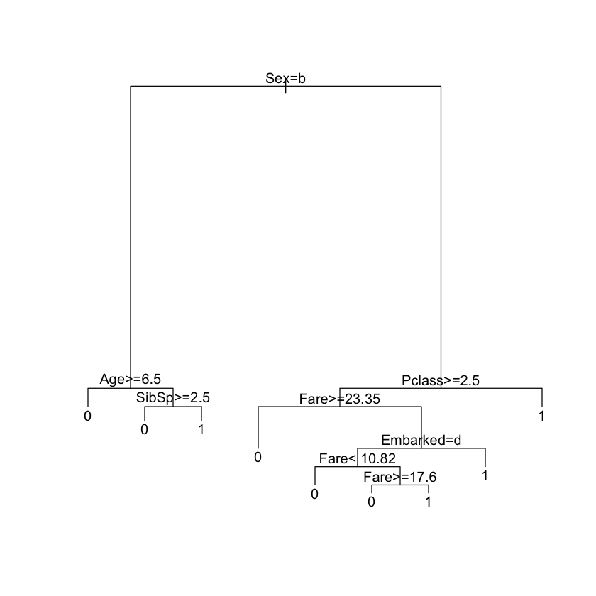

```r
plot(tree)
text(tree)
```

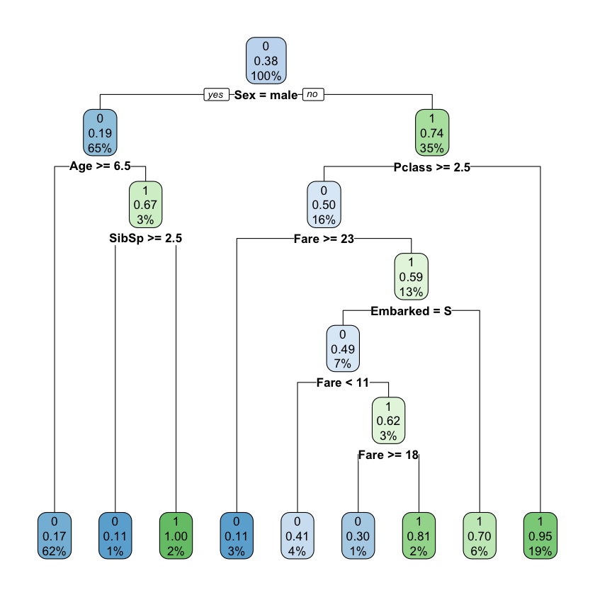

```r
rpart.plot(tree)
```

```r
summary(tree)
```

[output not shown]